# A brief epidemiologic examination of selected communicable diseases in the state of California

- Show All Code
- Hide All Code
- View Source

BMIN503/EPID600 Final Project

Author

Fang (Amy) Liu

Published

Last Updated: Dec 13, 2023

```r
library(tidyverse)
library(readr) #for reading in excel sheets
library(DT) #for making organized tables
library(RColorBrewer) #for fun color palettes
library(tigris) #to download boundary shapefiles from the US census bureau
library(sf)
options(tigris_use_cache = TRUE)
options(progress_enabled = FALSE)
```

# 1 Overview

For my final project, I am looking at trends in the case counts and rates of selected [infectious diseases reported in California](https://catalog.data.gov/dataset/infectious-diseases-by-disease-county-year-and-sex-d8912) from 2001 to 2021. California regulations require cases of [selected communicable diseases](https://www.cdph.ca.gov/Programs/CID/DCDC/CDPH%20Document%20Library/ReportableDiseases.pdf) to be reported to the California Department of Public Health (CDPH); CDPH work with and local health departments to monitor cases and to identify, control, and prevent infections. Broadly, I want to see if there is a increase in the number of cases for the Top 3 communicable diseases in the past two decades and assess their longitudinal trends over the years as well as looking at how cases are distributed spatially to identify potential hotspots. I spoke with two DBEI faculties (Quy Cao and Haochang Shou), as well as my coworker who is a wonderful data analyst. They provided valuable feedback on what to include, data visualizations, and coding. As well as asking questions that helped me dive a bit deeper into the dataset (e.g., doing more background research on the diseases, identifying potential reasons for increasing cases, and how surveillance aids decision-making). Overall, I had fun working with this dataset and hope to continue the analysis in the future by including more socioeconomic factors and running predictive models. The final project was a great exercise to utilize and apply all the R knowledge I gained this semester!

[Link to my final project GitHub Repo!](https://github.com/amyfliu/BMIN503_Final_Project)

# 2 Introduction

The California Department of Public Health (CDPH) maintains a passive reporting system for a list of communicable disease cases and outbreaks mandated by state law and regulation. A full list of selected communicable diseases can be found [here](https://www.cdph.ca.gov/Programs/CID/DCDC/CDPH%20Document%20Library/ReportableDiseases.pdf). Healthcare providers are required to report cases of these diseases to local health departments, which in turn report these cases to the CDPH. CDPH aggregate the information across all counties and surveillance data is shared with the Centers of Disease Control and Prevention (CDC). Tracking and monitor these diseases is very important because it helps us understand the magnitude and burden of specific diseases, quickly identify disease outbreaks, and also help us identify potential risk groups which we can then design targeted intervention strategies and actions, as well as assessing the effectiveness of any control or prevention efforts.

Surveillance is a fundamental bedrock of public health. When everything is normal, the public is unaware of the public surveillance that is occuring in the background. Only when there is a big outbreak will the public then realize the importance of active disease monitoring. Public health surveillance is itself a really interdisciplinary team effort - you need providers and laboratories reporting these cases to local health departments, which is potentially followed by fieldwork to examine and identify sources of outbreaks, then the Department of Health aggregates these information across regions and entire data analyst teams are dedicated to cleaning and extracting valuable information from the data to identify potential risk factors and inform future prevention planning. For my final project, I want to take the opportunity to get some hands-on practice on a actual surveillance dataset released by the CDPH, extract patterns and perform data analysis, and understand how surveillance contributes to protecting the public’s health.

Using the data, I want to answer a few key questions:

1. What are the most common reportale communicable diseases in California from 2001-2021?
2. What are the longitudinal trends of those diseases?
3. How are cases distributed geographically and how can we use that information to inform decision-making?

# 3 Methods

First, for exploratory analysis, I aggregated data across all years (2001 - 2021) for each reported disease and identified the top 10 diseases by cumulative case count. Next, I looked at the trend more closely year by year for the top 3 reportable communicable diseases to see if there has been a drastic decrease or increase in cases over the years. General trends for the diseases are described and possible explanations for the trends are provided when relevant, along with a brief overview of each disease. Next, I looked at the spatial distribution for each disease to identify which region or population are affected more using choropleth maps. All analyses were performed using R version 4.3.1.

```r
# load data dictionary
dictionary <- readxl::read_excel("~/Desktop/BMIN5030/final_project/data/data_dictionary.xlsx", skip = 1) %>%
  janitor::clean_names() %>%
  rename(variable = column_name) %>%
  select(variable, definition)

# load infectious disease data
infectious_data <- readr::read_csv("~/Desktop/BMIN5030/final_project/data/infectious_diseases_by_county_year_and_sex.csv") %>%
  janitor::clean_names()

# output the data in a nice table format
infectious_data %>%
  select(disease, county, year, sex, cases, population, rate) %>%
  filter(disease == "Malaria") %>%
  head(200) %>%
  datatable(
    caption = htmltools::tags$caption(
    style = 'caption-side: top; text-align: left;',
    'Table 1: Example of what the data looks like.'),
    options = list(scrollCollapse = T,
                         scrollY = '30vh',
                         scrollX = "50vh",
                         pageLength = 50))
```

|  | disease | county | year | sex | cases | population | rate |
| --- | --- | --- | --- | --- | --- | --- | --- |
| 1 | Malaria | Alameda | 2001 | Female | 2 | 746596 | 0.268* |
| 2 | Malaria | Alameda | 2001 | Male | 13 | 718968 | 1.808* |
| 3 | Malaria | Alameda | 2001 | Total | 15 | 1465564 | 1.023* |
| 4 | Malaria | Alameda | 2002 | Female | 10 | 747987 | 1.337* |
| 5 | Malaria | Alameda | 2002 | Male | 17 | 720481 | 2.360* |
| 6 | Malaria | Alameda | 2002 | Total | 27 | 1468468 | 1.839 |
| 7 | Malaria | Alameda | 2003 | Female | 7 | 747441 | 0.937* |
| 8 | Malaria | Alameda | 2003 | Male | 8 | 719746 | 1.112* |
| 9 | Malaria | Alameda | 2003 | Total | 15 | 1467187 | 1.022* |
| 10 | Malaria | Alameda | 2004 | Female | 1 | 746723 | 0.134* |

[output cut: 190 more lines]

Data Dictionary

| variable | definition |
| --- | --- |
| Disease | The name of the Infectious Diseases reported. |
| County | The county in which the case resided when they were diagnosed and State-wide total |
| Year | Estimated onset date is the date closest to the time when symptoms first appeared from 2001 - 2021 |
| Sex | The patient’s sex as reported by the provider |
| Cases | The # of cases reported per disease meeting the surveillance case definition by County, Year, and County. |
| Population | The estimated population size (rounded to the nearest integer) for each County, Year, Sex strata. |
| Rate | # of cases per 100,000 population per County, Year, and Sex |

# 4 Results

## 4.1 Exploratory analysis

> Identify the most common diseases.

```r
# find the total number of cases for each disease (2001 - 2021)
total_cases <- infectious_data %>%
  filter(county == "California") %>% #state level data
  filter(sex == "Total") %>%
  group_by(disease) %>%
  summarize(total_cases = sum(cases)) %>%
  arrange(desc(total_cases)) %>%
  head(10)

# Create a bar plot using ggplot2
common_diseases <- ggplot(total_cases,
       aes(#x = disease,
           x = fct_reorder(disease, total_cases),
           y = total_cases)) +
  geom_bar(stat = "identity", fill = "skyblue") +
  labs(title = "Top 10 Reportable Communicable Diseases by Cumulative Case Count",
       subtitle = "California, 2001 - 2021",
       x = "Disease", y = "Total Cases") +
  theme_bw() +
  theme(axis.text.x = element_text(angle = 45, hjust = 1)) +  # Rotate x-axis labels for readability
  coord_flip()  # Flip the plot horizontally

# Save the plot as an image (e.g., PNG)
#ggsave("top_diseases.png", plot = common_diseases)
```

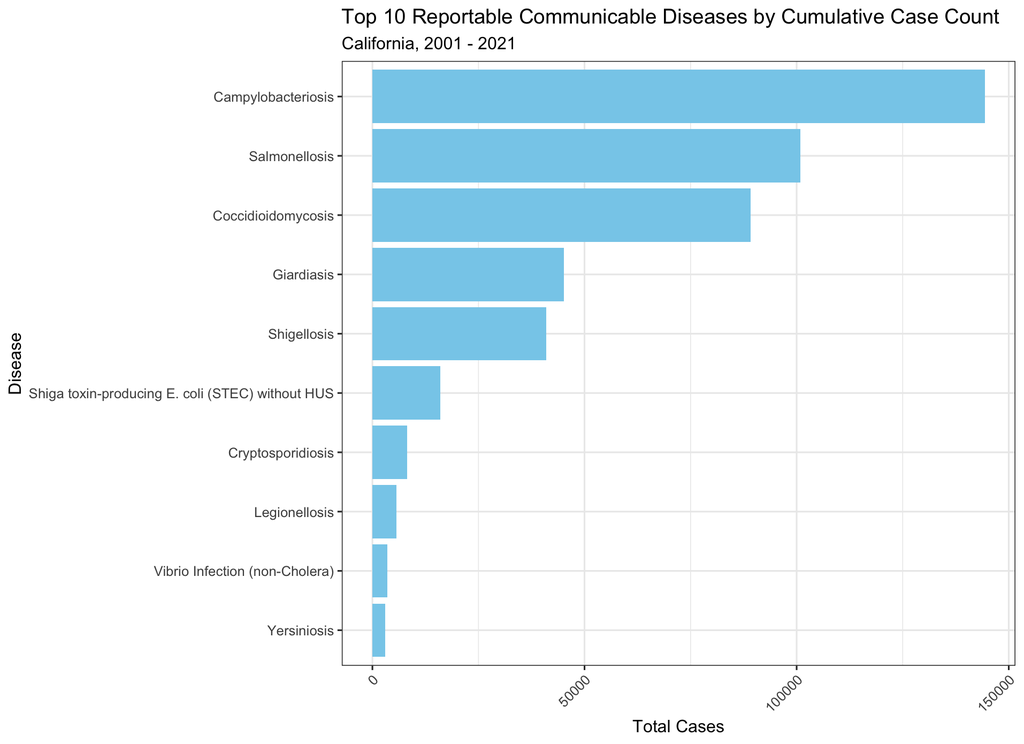

**The top 3 diseases by case count is Campylobacteriosis, Salmonellosis, and Coccidioidomycosis.**

> Look at the trend in top diseases in the past two decades.

**Campylobacteriosis**

*Campylobacter* is the #1 cause of bacterial diarrheal illness in the United States. CDC estimates 1.5 million illnesses each year in the US. People usually get infected by eating raw or undercooked poultry. Common symptoms include diarrhea, fever, stomach cramps, and also nausea/vomiting. Symptoms usually start 2-5 days after person ingests *Campylobacter* and last about one week. Fortunately, most people recover without antibiotic treatment. However, those at risk for severe illnesses might need antibiotic treatment (i.e., 65+, pregnant women, people with weakened immune systems).

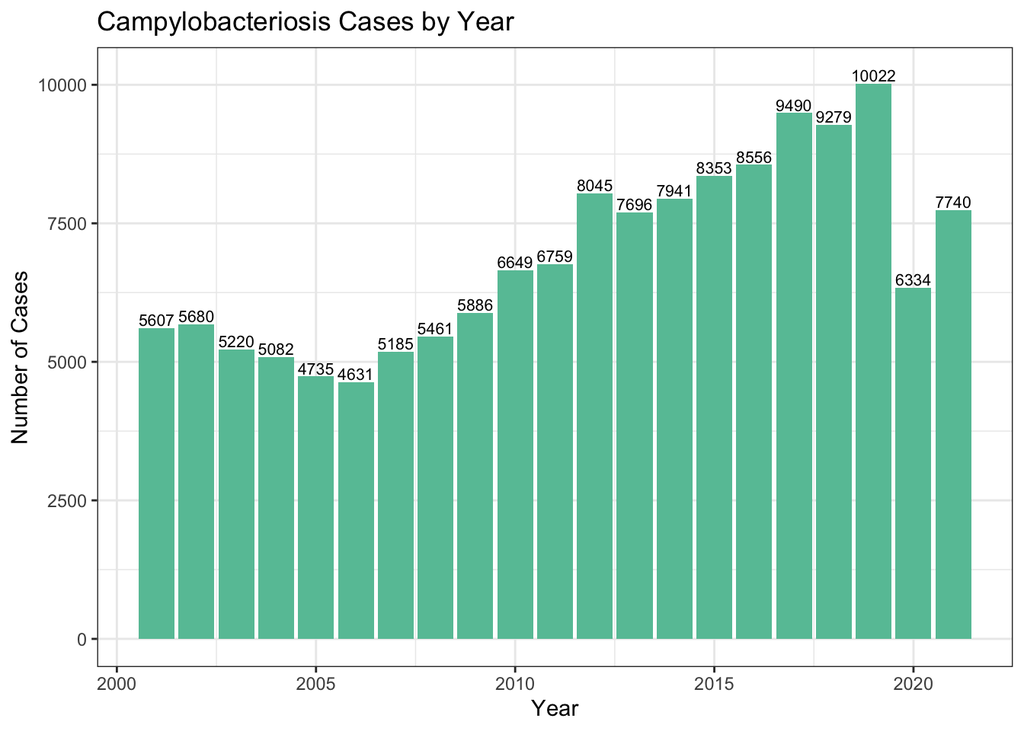

```r
# find the number of cases and incidence rate for each disease, at each year
diseases <- infectious_data %>%
  filter(county == "California") %>% #state level data
  filter(sex == "Total") %>% #across all cases
  mutate(rate = (cases *100000)/population) %>% #calculate the rate
  #mutate(rate = as.numeric(rate)) %>%  #convert rate to numeric
  #filter(cases > 0) %>%
  select(disease, year, cases, rate)

# Create a bar plot for Campylobacteriosis cases
diseases %>% filter(disease == "Campylobacteriosis") %>%
  ggplot(aes(x = year, y = cases)) +
  geom_bar(stat = "identity", fill = "#66c2a5") +
  geom_text(aes(label = signif(cases)), nudge_y = 150, size = 2.8) +
  labs(title = "Campylobacteriosis Cases by Year", x = "Year", y = "Number of Cases") +
  theme_bw()
```

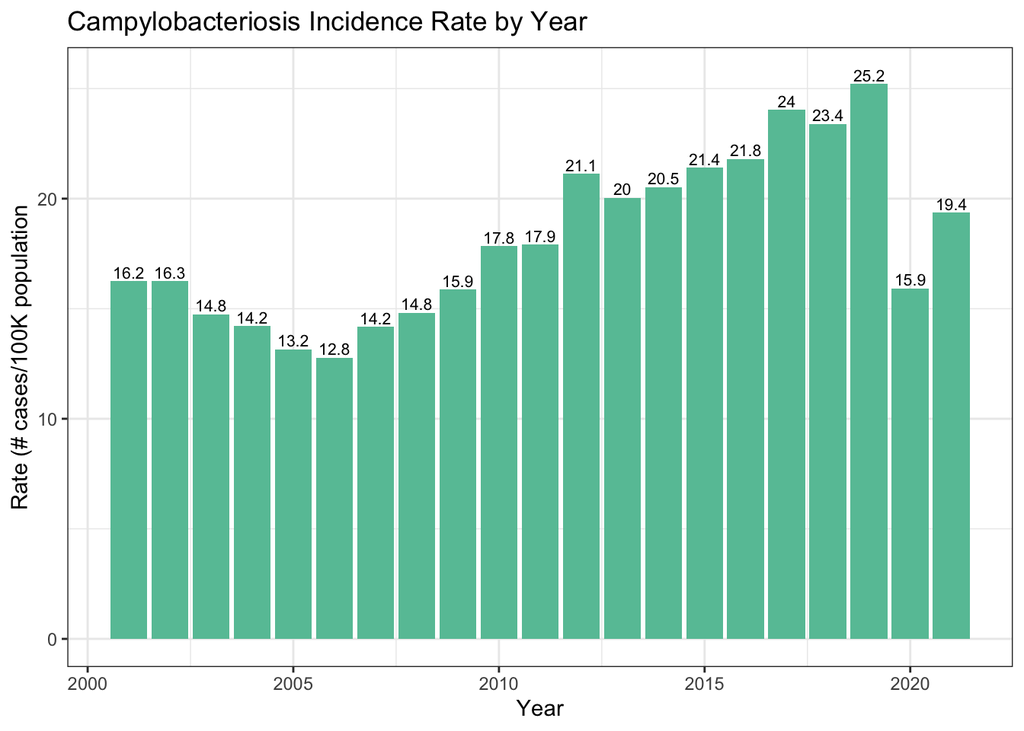

```r
# bar plot of incidence rates
diseases %>% filter(disease == "Campylobacteriosis") %>%
  ggplot(aes(x = year, y = rate)) +
  geom_bar(stat = "identity", fill = "#66c2a5") +
  geom_text(aes(label = round(rate,1)), nudge_y = 0.4, size = 2.8) +
  labs(title = "Campylobacteriosis Incidence Rate by Year", x = "Year", y = "Rate (# cases/100K population") +
  theme_bw()
```

**Findings**

From the case and incidence rates trends above, we see that the number of people who get sick from the *Campylobacter* bacteria has been increasing steadily since 2006. In fact, the # of cases have more than doubled from 2006 (4631 cases) to 2019 (10022 cases). The significant drop observed in year 2020 is likely impacted by COVID, an timepoint at which most health resources are divested toward controlling the new SARs-Cov2 Virus. Another reason why we see this drop is people eating out less so there are fewer food-related outbreaks.

**Salmonellosis**

Salmonellosis is an infection with a bacteria called *Salmonella*, which usually live in the intestinal tracts of animals. Salmonella are usually transmitted to humans by eating foods contaminated with animal feces. Contaminated foods are often of animal origin (e.g., poultry, pork, poultry, etc). Common symptoms include diarrhea, abdominal pain and cramps, and fever.

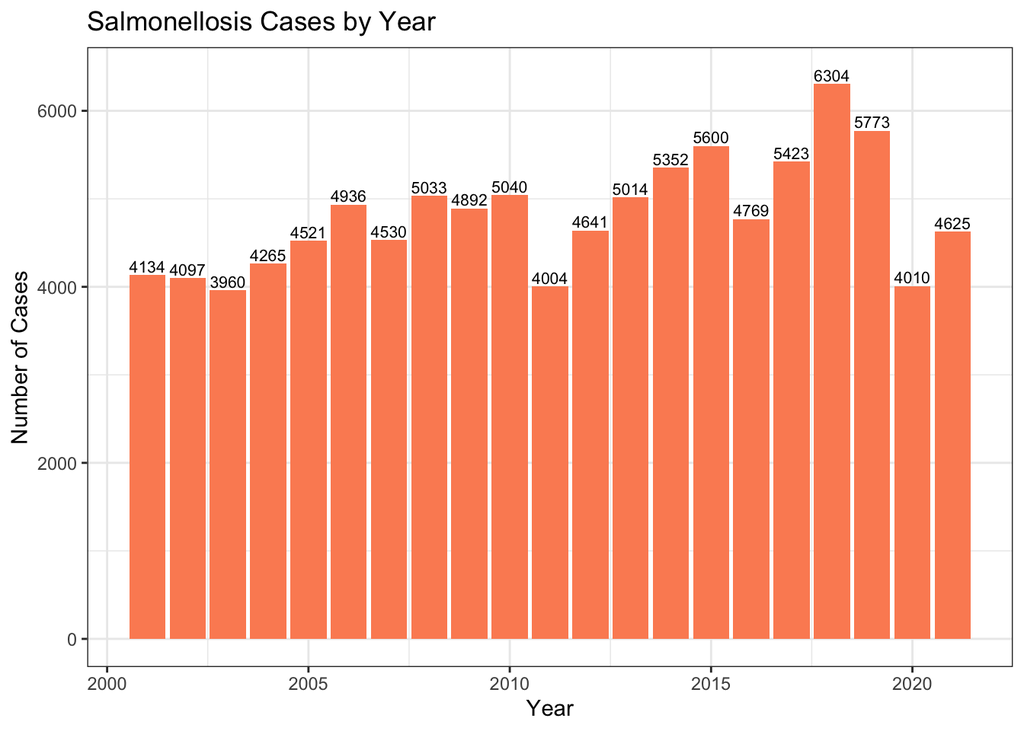

```r
disease_of_interest <- "Salmonellosis"

diseases %>% filter(disease == disease_of_interest) %>%
  ggplot(aes(x = year, y = cases)) +
  geom_bar(stat = "identity", fill = "#fc8d62") +
  geom_text(aes(label = signif(cases)), nudge_y = 100, size = 2.8) +
  labs(title = paste0(disease_of_interest, " Cases by Year"), x = "Year", y = "Number of Cases") +
  theme_bw()
```

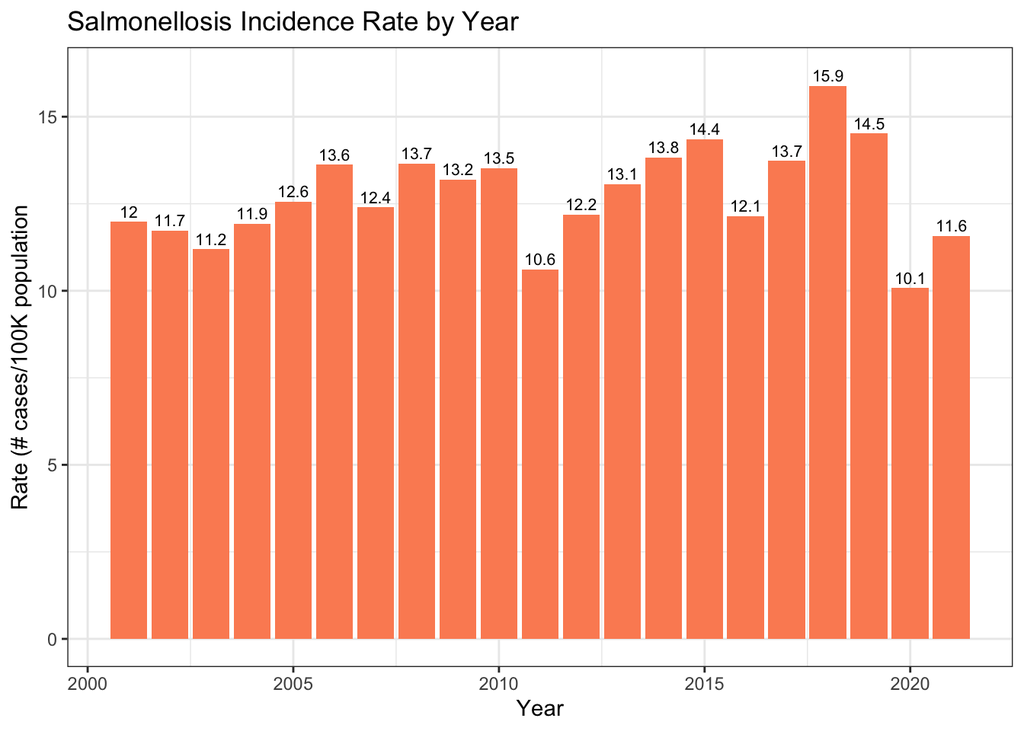

```r
diseases %>% filter(disease == disease_of_interest) %>%
  ggplot(aes(x = year, y = rate)) +
  geom_bar(stat = "identity", fill = "#fc8d62") +
  geom_text(aes(label = round(rate,1)), nudge_y = 0.3, size = 2.8) +
  labs(title = paste0(disease_of_interest, " Incidence Rate by Year"), x = "Year", y = "Rate (# cases/100K population") +
  theme_bw()
```

**Findings**

The incidence rate of Salmonellosis is more stable compared to that for Campylobacteriosis; the incidence rate have fluctuated between 10 to 16 cases per 100K population. Again, note the drastic decrease in Salmonellosis due to COVID-19.

**Coccidioidomycosis**

Cocci or Valley fever is a disease caused by a fungus that grows in the soil and dirt in some areas of California and southwestern US. People get sick when they breathe in dust that contains Valley fever fungus. Valley fever can be serious and fatal. Currently there is no vaccine to prevent cocci but antifungals medications are available.

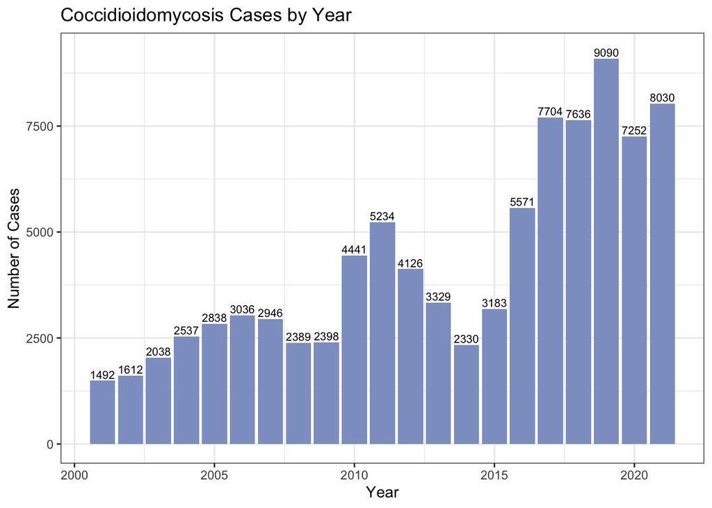

```r
disease_of_interest <- "Coccidioidomycosis"

diseases %>% filter(disease == disease_of_interest) %>%
  ggplot(aes(x = year, y = cases)) +
  geom_bar(stat = "identity", fill = "#8da0cb") +
  geom_text(aes(label = signif(cases)), nudge_y = 150, size = 2.8) +
  labs(title = paste0(disease_of_interest, " Cases by Year"), x = "Year", y = "Number of Cases") +
  theme_bw()
```

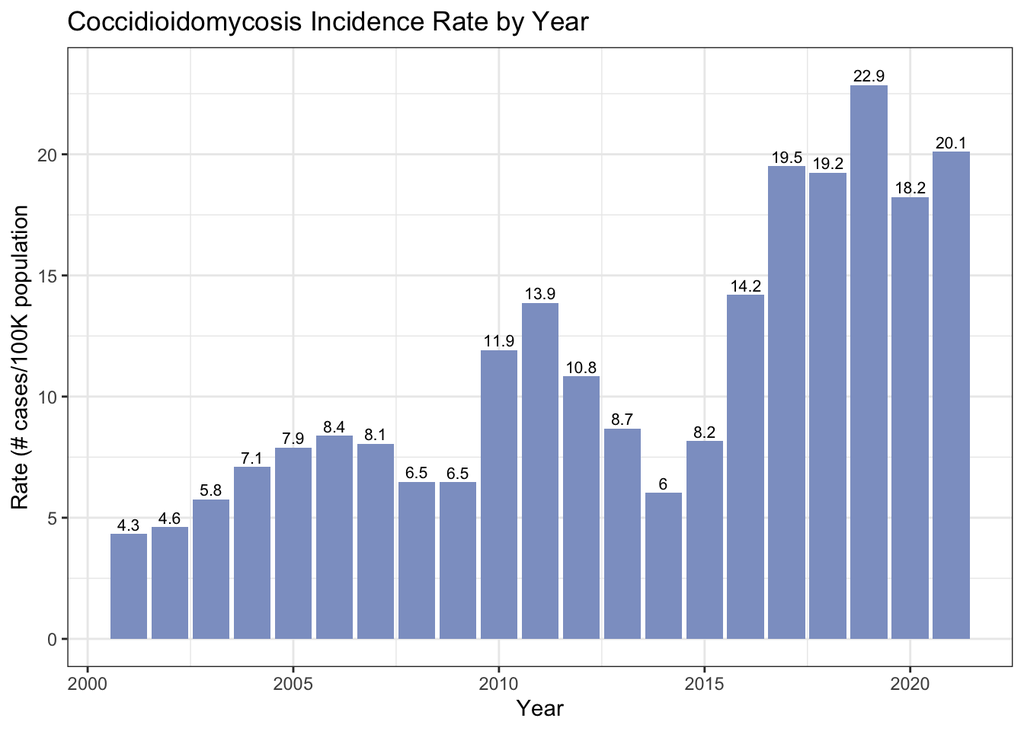

```r
diseases %>% filter(disease == disease_of_interest) %>%
  ggplot(aes(x = year, y = rate)) +
  geom_bar(stat = "identity", fill = "#8da0cb") +
  geom_text(aes(label = round(rate,1)), nudge_y = 0.4, size = 2.8) +
  labs(title = paste0(disease_of_interest, " Incidence Rate by Year"), x = "Year", y = "Rate (# cases/100K population") +
  theme_bw()
```

**Findings**

The number of cases and incidence rate of Valley Fever have increased drastically over the years. The incidence rate is only 4.3 cases (per 100K population) in 2001 but increased to more than than 22.9 in 2019. Note that the drop in cases in 2020 is not as drastic as compared to the other two diseases. Because Coccidioidomycosis usually affect those who work in the field and farming is still an essential activity despite of the pandemic, field workers are likely to be still working and thus at risk of Cocci infection.

## 4.2 Spatial distribution of diseases

### 4.2.1 Campylobacteriosis

```r
# average annual incidence rate by county
avg_rates <- infectious_data %>%
  filter(disease == "Campylobacteriosis") %>%
  filter(county != "California") %>% #state level data
  filter(sex == "Total") %>%
  mutate(rate2 = cases * 100000/population) %>%
  select(county, year, rate2) %>%
  group_by(county) %>%
  summarize(avg_rate = round(mean(rate2),3)) %>%
  arrange(desc(avg_rate))

# table of 95% CI for each lesion
datatable(avg_rates,
          caption = htmltools::tags$caption(
            style = 'caption-side: top; text-align: left;',
            'Table 2: Average annual rate of new campylobacteriosis cases by county.'),
          options = list(scrollCollapse = T,
                         scrollY = '30vh',
                         scrollX = "30vh",
                         pageLength = 30))
```

|  | county | avg_rate |
| --- | --- | --- |
| 1 | San Francisco | 45.46 |
| 2 | Tulare | 32.998 |
| 3 | Madera | 32.522 |
| 4 | Mendocino | 31.71 |
| 5 | Marin | 30.823 |
| 6 | San Mateo | 30.535 |
| 7 | Napa | 29.655 |
| 8 | Stanislaus | 29.321 |
| 9 | Fresno | 28.171 |
| 10 | Butte | 26.498 |

[output cut: 48 more lines]

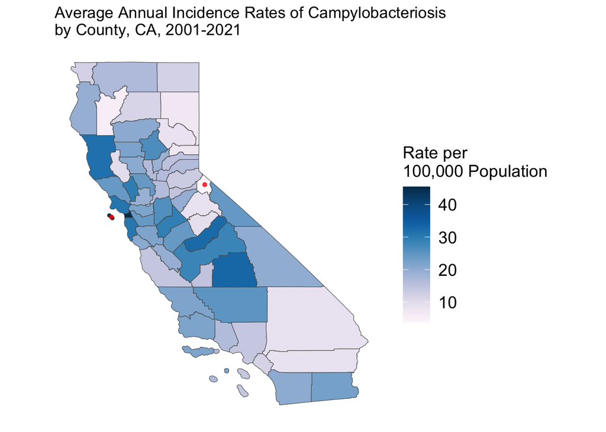

```r
# load counties shapefile for CA
ca_2021 <- tigris::counties(state = "CA", year = 2021)

# join two datasets so we have the incidence data for each county
ca_2021_rates <- inner_join(ca_2021, avg_rates,
                             by = c("NAME" = "county"))

my_theme <- function() {
  theme_minimal() +  # shorthand for white background color
  theme(axis.line = element_blank(),  # further customization of theme components
        axis.text = element_blank(),  # remove x and y axis text and labels
        axis.title = element_blank(),
        panel.grid = element_line(color = "white"),  # make grid lines invisible
        legend.key.size = unit(0.8, "cm"),           # increase size of legend
        legend.text = element_text(size = 14),       # increase legend text size
        legend.title = element_text(size = 14))      # increase legend title size
}

# customized plot
myPalette <- colorRampPalette(brewer.pal(9, "PuBu"))  # RColorBrewer palette

# plot a point on the map
places.df <- data.frame(places = c("San Francisco", "Alpine"),
                 lat = c(37.7272391,
                         38.6217831),
                 lon = c(-123.0322294,
                         -119.7983522))

my_locations_sf <- st_as_sf(places.df, coords = c("lon", "lat"),
                            crs = 4326)

ggplot() +
  geom_sf(data = ca_2021_rates, aes(fill = avg_rate)) +
  geom_sf(data = my_locations_sf, color = "red", alpha = 0.8, size = 1.2) +
  my_theme() +
  ggtitle("Average Annual Incidence Rates of Campylobacteriosis \nby County, CA, 2001-2021") +
  scale_fill_gradientn(name = "Rate per \n100,000 Population",
                    colours = myPalette(100))
```

**Findings**

The average annual rate of new campylobacteriosis cases during 2001-2021 was about 19 cases per 100,000 people in California. The average rates were highest in San Francisco County (about 45 cases per 100,000 people) and lowest in Alpine County (4 cases per 100,000 people).

### 4.2.2 Salmonellosis

```r
targeted_disease <- "Salmonellosis"

avg_rates <- infectious_data %>%
  filter(disease == targeted_disease) %>%
  filter(county != "California") %>% #state level data
  filter(sex == "Total") %>%
  mutate(rate2 = cases * 100000/population) %>%
  select(county, year, rate2) %>%
  group_by(county) %>%
  summarize(avg_rate = round(mean(rate2),3)) %>%
  arrange(desc(avg_rate))

# table of 95% CI for each lesion
datatable(avg_rates,
          caption = htmltools::tags$caption(
            style = 'caption-side: top; text-align: left;',
            'Table 3: Average annual rate of new Salmonellosis cases by county.'),
          options = list(scrollCollapse = T,
                         scrollY = '30vh',
                         scrollX = "30vh",
                         pageLength = 30))
```

|  | county | avg_rate |
| --- | --- | --- |
| 1 | Imperial | 22.437 |
| 2 | San Benito | 19.608 |
| 3 | San Mateo | 16.989 |
| 4 | San Francisco | 16.561 |
| 5 | Santa Clara | 16.31 |
| 6 | Madera | 16.008 |
| 7 | San Diego | 15.644 |
| 8 | Butte | 15.353 |
| 9 | Tulare | 15.26 |
| 10 | Alameda | 15.202 |

[output cut: 48 more lines]

```r
# join two datasets so we have the incidence data for each county
ca_2021_sal <- inner_join(ca_2021, avg_rates,
                             by = c("NAME" = "county"))
```

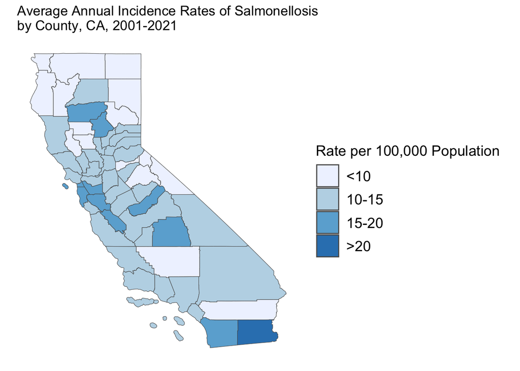

```r
# Define the bin breaks and labels for your specific data
bin_breaks <- c(0, 10, 15, 20, Inf)
bin_labels <- c("<10", "10-15", "15-20", ">20")

# Create a new column that categorizes avg_rate into bins
ca_2021_sal$rate_category <- cut(ca_2021_sal$avg_rate,
                                   breaks = bin_breaks,
                                   labels = bin_labels,
                                   right = FALSE)

# Create a custom color palette for the categories
custom_palette <- c("#eff3ff", "#bdd7e7","#6baed6","#3182bd")

# Create the choropleth map with the custom palette
ggplot() +
  geom_sf(data = ca_2021_sal, aes(fill = rate_category)) +
  my_theme() +
  ggtitle("Average Annual Incidence Rates of Salmonellosis \nby County, CA, 2001-2021") +
  scale_fill_manual(name = "Rate per 100,000 Population",
                    values = setNames(custom_palette, levels(ca_2021_sal$rate_category)))+
  labs(fill = "Rate Category")
```

**Findings**

The average annual rate of new Salmonellosis cases during 2001-2021 was about 12 cases per 100,000 people in California. The average rates were highest in Imperial County (22 cases per 100,000 people) and lowest in Alpine County (4 cases per 100,000 people).

### 4.2.3 Coccidioidomycosis

```r
targeted_disease <- "Coccidioidomycosis"

avg_rates <- infectious_data %>%
  filter(disease == targeted_disease) %>%
  filter(county != "California") %>% #state level data
  filter(sex == "Total") %>%
  mutate(rate2 = cases * 100000/population) %>%
  select(county, year, rate2) %>%
  group_by(county) %>%
  summarize(avg_rate = round(mean(rate2),3)) %>%
  arrange(desc(avg_rate))

# table of 95% CI for each lesion
datatable(avg_rates,
          caption = htmltools::tags$caption(
            style = 'caption-side: top; text-align: left;',
            'Table 4: Average annual rate of new Coccidioidomycosis cases by county.'),
          options = list(scrollCollapse = T,
                         scrollY = '30vh',
                         scrollX = "30vh",
                         pageLength = 30))
```

|  | county | avg_rate |
| --- | --- | --- |
| 1 | Kern | 207.239 |
| 2 | Kings | 114.523 |
| 3 | San Luis Obispo | 52.607 |
| 4 | Fresno | 44.368 |
| 5 | Tulare | 43.402 |
| 6 | Madera | 22.92 |
| 7 | Merced | 18.985 |
| 8 | Monterey | 16.271 |
| 9 | San Joaquin | 12.19 |
| 10 | Ventura | 11.792 |

[output cut: 48 more lines]

```r
# join two datasets so we have the incidence data for each county
ca_2021_cocci <- inner_join(ca_2021, avg_rates,
                             by = c("NAME" = "county"))
```

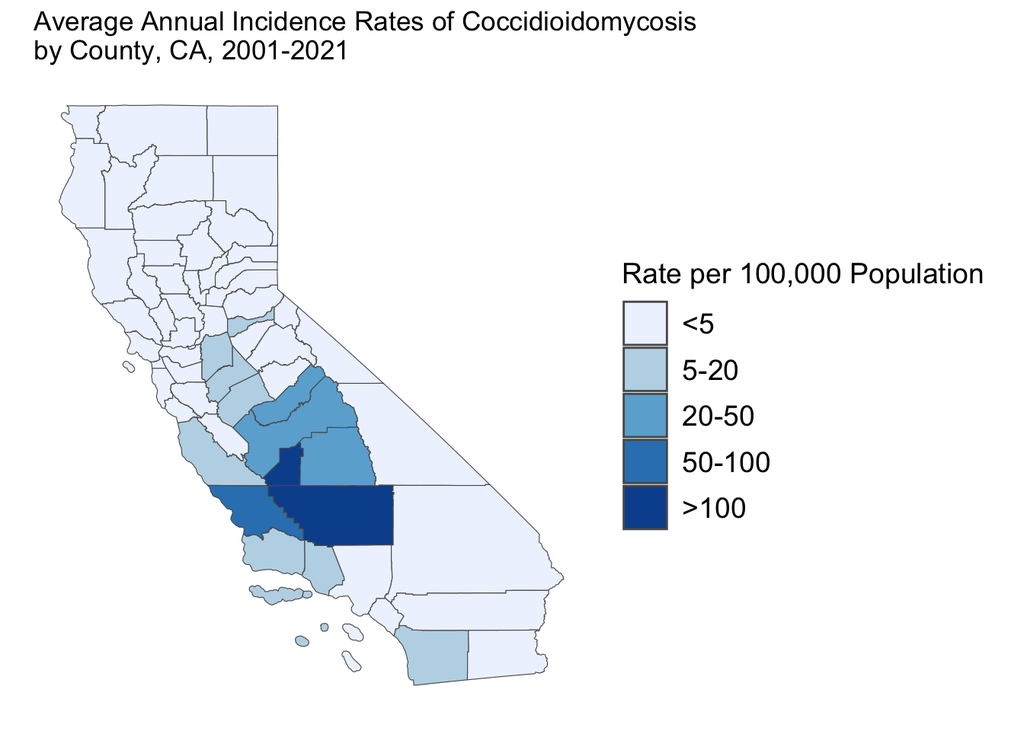

```r
# Define the bin breaks and labels for your specific data
bin_breaks <- c(0, 5, 20, 50, 100, Inf)
bin_labels <- c("<5", "5-20", "20-50", "50-100", ">100")

# Create a new column that categorizes avg_rate into bins
ca_2021_cocci$rate_category <- cut(ca_2021_cocci$avg_rate,
                                   breaks = bin_breaks,
                                   labels = bin_labels,
                                   right = FALSE)

# Create a custom color palette for the categories
custom_palette <- c("#eff3ff", "#bdd7e7","#6baed6","#3182bd", "#08519c")

# Create the choropleth map with the custom palette
ggplot() +
  geom_sf(data = ca_2021_cocci, aes(fill = rate_category)) +
  my_theme() +
  ggtitle("Average Annual Incidence Rates of Coccidioidomycosis \nby County, CA, 2001-2021") +
  scale_fill_manual(name = "Rate per 100,000 Population",
                    values = setNames(custom_palette, levels(ca_2021_cocci$rate_category)))+
  labs(fill = "Rate Category")
```

**Findings**

The average annual incidence rate of Coccidioidomycosis from 2001 to 2021 was highest in Kern County (207 per 100,000), followed by Kings County (114 per 100,000). Overall, most cases of Valley fever in California are reported in people who live in the Central Valley and Central Coast regions.

# 5 Discussion & Limitations

For this study, I conducted a brief epidemiologic examination of selected communicable diseases in the state of California. Using publicly available data from the California Department of Public Health (CDPH), I looked at the top 3 reportable communicable diseases by cumulative case count within the years 2001-2021 and examined the annual trends. The top two disease, Campylobacteriosis and Salmonellosis, are both bacterial infections, usually via contact with raw/undercooked food or foods contaminated with the bacteria. To mitigate foodborne disease infection and outbreaks in the future, we need to prevent contamination during the processing and production of foods. In addition, to prevent outbreaks in the long term, we need to implement food safety practices and work with partners throughout the food production chain. As with any other public health issue, it is also important to educate people about food safety practices such as washing hands thoroughly before preparing or eating food, after using the toilet, etc. Geographically, food-borne outbreaks are more frequent in more populous areas such as San Francisco from the results. However, this could be an artifact of health resource availability. For instance, many smaller and rural hospitals might not have the resources to conduct and report cultures studies for these diseases; many infections might go untested and unreportabled in less populated locations. Thus, to have more reliability surveillance, there is a need to strengthen surveillance systems across the state in the future.

Unlike the first two bacterial diseases, the 3rd disease Coccidioidomycosis (or Valley Fever) is a fungal infection caused by inhalation of a fungus that grows in the soil and dirt. Valley Fever infections is most common is some areas of California and southwestern US such as Arizona. Because valley fever can be serious and fatal, proactive prevention strategies are needed. Currently there is no vaccine to prevent the disease but antifungal medications are available. In California, most cases are reported in people who live in the Central Valley and Central Coast regions. Central Valley is known for its agricultural productivity, in fact, it provides more than half of fruits,vegetables, and nuts grown in the US. Those at higher risk of infection include people participate in outdoor activities that involve close contact with dirt or dust, including construction and farming. To reduce the likelihood of infection for these populations, we need to promote activities such as wetting down soil before disturbing to reduce dust or wearing an N95 mask or respirator. Education campaigns will also be very helpful to raise awareness of the disease.

To conclude, this project was a great exercise for me to use an actual surveillance dataset to extract patterns and see how data can be used to inform decision-making. Through the exercise, I also realized the importance of tracking and monitoring of communicable diseases - understanding the magnitude and burden of specific diseases informs allocation of resources and helps identify potential risk groups. Having surveillance data available helps us design targeted intervention strategies and also assess the effectiveness of control or prevention efforts. With increasing globalization and climate change, we will likely experience more spill-over events in the future so having a active and strong surveillance system is vitally important in detecting new cases and outbreaks. **Surveillance is a fundamental bedrock of public health!**

# 6 Relevant Links

- [Downloadable data for this project](https://catalog.data.gov/dataset/infectious-diseases-by-disease-county-year-and-sex-d8912)
- [Epidemiologic Summaries of Selected Communicable Diseases in California](https://www.cdph.ca.gov/Programs/CID/DCDC/Pages/EpiSummariesofCDsCA.aspx)
- [List of reportable communicable diseases for California](https://www.cdph.ca.gov/Programs/CID/DCDC/CDPH%20Document%20Library/ReportableDiseases.pdf)
- [Examples of Infectious diseases case report forms](https://www.cdph.ca.gov/Programs/PSB/Pages/CommunicableDiseaseControl.aspx)
- [CDC Campylobacter Page](https://www.cdc.gov/campylobacter/index.html)
- [CDPH Valley Fever Page](https://www.cdph.ca.gov/Programs/CID/DCDC/Pages/Coccidioidomycosis.aspx)